# Exploration of effect of loan features on Borrower APR

## by Francisco Pineda

## Investigation Overview

> In this investigation, I wanted to look at the characteristics of loans that could be used to predict the borrower APR. The main focus was on prosper rating, credit score upper limit and Estimated Return.

## Dataset Overview

> The data consisted of the parameters of approximately 113000 loans. The attributes include Borrower APR, Prosper Rating, Credit Score, and Estimated Return. I Created new DataFrames for different visualzations where I removed loans that did not have those parameters.

## Borrower APR Distribution

> APRs range from nearly zero to over .4. There appears to be a slight right skew to the distribution.

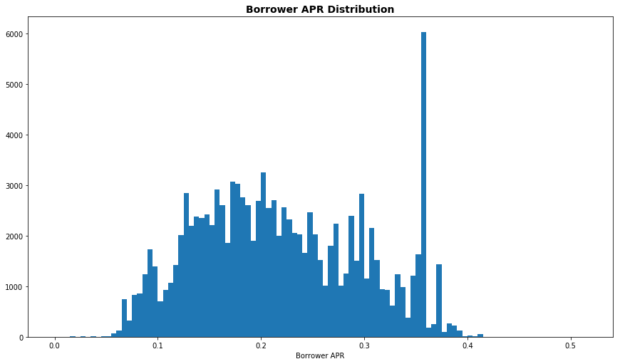

```python
#distrubtion of Borrower APR
binsize = .005
bins = np.arange(0, df['BorrowerAPR'].max()+binsize, binsize)

plt.figure(figsize=[14.70, 8.27])
plt.hist(data = df, x = 'BorrowerAPR', bins = bins,range=(0,1) )
plt.title("Borrower APR Distribution", fontsize =14, weight = "bold")
plt.xlabel('Borrower APR')
plt.show()
```

## Credit Score Range Upper Distribution

> This shows the distribution of Credit Score Range Upper for Each loan. It appears roughly normal.

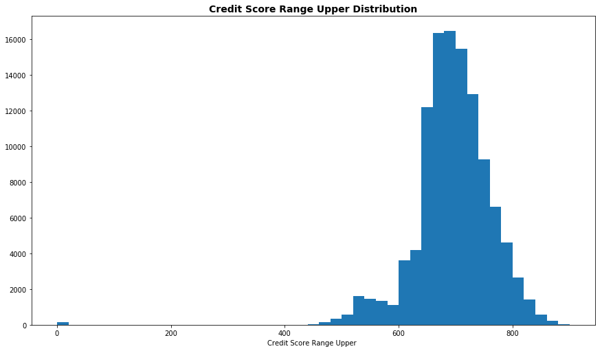

```python
binsize = 20
bins = np.arange(0, df['CreditScoreRangeUpper'].max()+binsize, binsize)
plt.figure(figsize=[14.70, 8.27])
plt.hist(data = df, x = 'CreditScoreRangeUpper', bins = bins,range=(0,1) )
plt.title("Credit Score Range Upper Distribution", fontsize =14, weight = "bold")
plt.xlabel('Credit Score Range Upper ')
plt.show()
```

> This shows a strong negative correlation between Borrower APR and and Prosper Rating

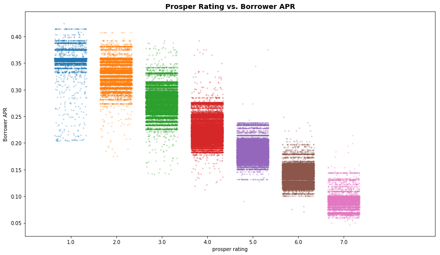

```python
plt.figure(figsize=[14.70, 8.27])
sb.stripplot(data =  df_ProsperRating,
             x = 'ProsperRating (numeric)', y = 'BorrowerAPR', alpha = 0.3, jitter = .35, size = 3)
plt.xlim([-1, 8])
plt.title("Prosper Rating vs. Borrower APR", fontsize =14, weight = "bold")
plt.xlabel('prosper rating')
plt.ylabel('Borrower APR')
plt.show()
```

## Estimated Return Vs Borrower APR

> This shows a moderate correlation between Borrower APR and Estimated Return

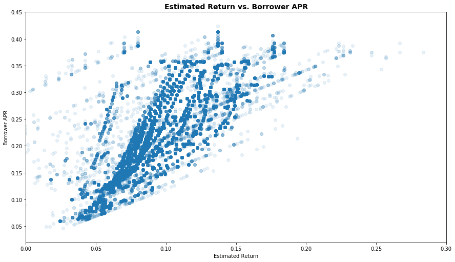

```python
plt.figure(figsize=[14.70, 8.27])
plt.scatter(data = df_EstimatedReturn, x = 'EstimatedReturn', y = 'BorrowerAPR', alpha = 1/10)
plt.xlim([0, .3])
plt.xlabel('Estimated Return')
plt.ylabel('Borrower APR')
plt.title("Estimated Return vs. Borrower APR", fontsize =14, weight = "bold")
plt.show()
```

## Credit Score Range Upper Vs Borrower APR Vs Prosper Rating

> This shows that the higher the prosper rating the lower the Borrower APR and higher the credit score range upper is.

```
Text(0,0.5,'Borrower APR')
```

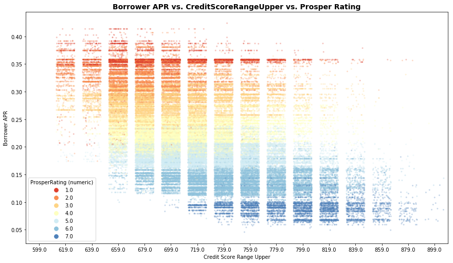

```python
plt.figure(figsize=[14.70, 8.27])
sb.stripplot(data =  df[df.CreditScoreRangeUpper > 590],
             x = 'CreditScoreRangeUpper', y = 'BorrowerAPR',  hue ='ProsperRating (numeric)',
             palette = "RdYlBu", alpha = 0.3, jitter = .35, size = 3)



plt.title('Borrower APR vs. CreditScoreRangeUpper vs. Prosper Rating', fontsize =14, weight = "bold")
plt.xlabel('Credit Score Range Upper')
plt.ylabel('Borrower APR')
```

## Credit Score Range Upper Vs Esimated Return Vs Prosper Rating

> This shows that the higher the credit scor range upper the higher the Prosper Rating and the less variability there is in the Estimated Return.

```
(-0.1, 0.2)
```

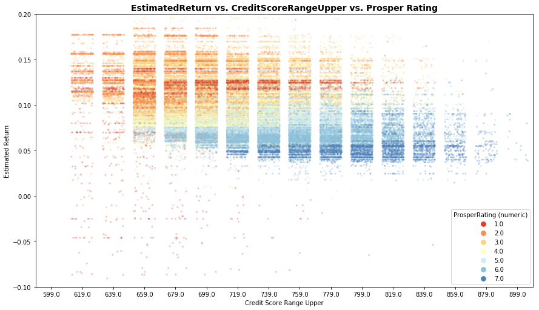

```python
plt.figure(figsize=[14.70, 8.27])

sb.stripplot(data =  df[df.CreditScoreRangeUpper > 590],
             x = 'CreditScoreRangeUpper', y = 'EstimatedReturn',  hue ='ProsperRating (numeric)',
             palette = "RdYlBu", alpha = 0.3, jitter = .35, size = 3)


plt.title('EstimatedReturn vs. CreditScoreRangeUpper vs. Prosper Rating', fontsize =14, weight = "bold")
plt.xlabel('Credit Score Range Upper')
plt.ylabel('Estimated Return')
plt.ylim([-0.1, 0.2])
```

```python
!jupyter nbconvert slide_deck_ProsperPineda.ipynb --to slides --post serve --template output_toggle
```

[output not shown]